# First we will need to set up your working directory

1. Set up working director:
   - Download “Download Data and Scripts”, in your download directory, you will see rscripting_workshop.zip, unzip it and copy rscripting_workshop folder into “RNanoCourse”
   - Click Session - Choose Directory -> Desktop -> RNanoCourse -> rscripting_workshop

# Writing your own functions

> The basics of a function are: FunctionName <- function(args1,args2, …) { statements return (something) }
1. Writing a simple function. Paste the following code in your console.

```r
SumOfNumbers <- function(x,y) {
  z = x + y
  return (z)
}
```

This is a a simple function called SumOfNumbers, which takes two arguments x and y and returns their sum.

2. Use the function SumOfNumbers to add x=35 and y=43?
3. Create a function SumOfSquares which takes two arguments x and y and returns the sum of the squares
4. Functions can return a list of multiple arguments for more complex calculations, using the list() function

```r
MultipleCalculations <- function(x,y) {
  z = x + y
  c = x^2 + y^2
  a = list(result1=z, result2=c)
  return (a)
}
```

5. Try the function on MultipleCalculations on x=5 and y=4? What does it return
6. Functions can take a variety of argument types
- single numbers
- vectors
- matrices

Make the vectors v1 and v2 and use the function SumOfNumbers to add the two. What is the result?

```r
v1 <- c(1,4,5)
v2 <- c(-1,20,3)
SumOfNumbers(v1,v2)
```

```
## [1]  0 24  8
```

Make the matrices m1 and m2 and use the function SumOfSquares to get the sum of squares the two. What is the result?

```r
m1 <- matrix( c(4, 3, -3, 1, -3, 4), ncol=2)
m2 <- matrix( c(-2, 2, -2, 0 , 5, 2), ncol=2)
```

### Summary:

- Keep your functions short.
- Add comments on what inputs are, what the function does and what is the output.
- Check for errors along the way.
- Try out your function with simple examples to make sure itâs working properly

# Loops

We have written function that perform a single operation. But we want to write a function that can be used many times to do the same operation on lots of different data.

- For: Allows operations to be executed repeatedly
- While: Allows operations to be executed repeatedly until a condition is meet
- Repeat: Allows operations to be executed repeatedly until a a user defined condition is meet

## For Loops

The for loop is used when iterating through a list.

7. A simple for loop that prints out numbers 1 through 4:

```r
for(i in 1:4) {
    print(i)
}
```

```
## [1] 1
## [1] 2
## [1] 3
## [1] 4
```

8. Create a matrix and find the sum of each row.

```r
example.matrix <- matrix( c(4, 8, 31, 1, 0, 20, 10, 20, 15,12, 34, 2), ncol=4)

MatrixRowSum <- function(m){
    vector.row <- matrix()
    for (i in 1:nrow(m)){
        row.sum <- 0
        for (j in 1:ncol(m)){
            row.sum <- row.sum + m[i,j]
        }
        vector.row[i] <- row.sum
    }
    return(vector.row)
}

MatrixRowSum(example.matrix)
```

```
## [1] 27 62 68
```

9. Write the a function, MatrixRowMean to find the mean of each row for example.matrix.

## Apply functions

There are several function in R that allow you to apply some function to a series of objects (eg. vectors, matrices, dataframes or files). They include:

- apply : Applies a function to every column or row of an array and returns the results in an array.
- lapply: Applies a function to elements in a list or a vector and returns the results in a list.
- sapply: Applies a function to elements in a list and returns the results in a vector, matrix or a list.
- tapply: Applies a function to each cell of an array.

> apply(X, MARGIN, FUN, …)
- X : Array or Matrix
- Margin: Specify which margin we want to apply the function to and which margin we wish to keep. If the array we are using is a matrix then we can specify the margin to be either 1 (apply the function to the rows) or 2 (apply the function to the columns).
- FUN: Can be any function that is built in or user defined to be applied to X
- …: Additional arguments for that will be passed to the function.
10. Example of finding the sum of each row using the apply function.

```r
apply(example.matrix,1,sum)
```

```
## [1] 27 62 68
```

11. Find the mean and the median of each row using the apply function.

# Writing Scripts

An R script is simply a text file containing the same commands that you would enter on the command line of R.

## Plotting

### Boxplots

A standard way of showing the distribution of the data.

12. Load iris sample data and install necessary packages. Make a boxplot of Sepal.Length by Species.

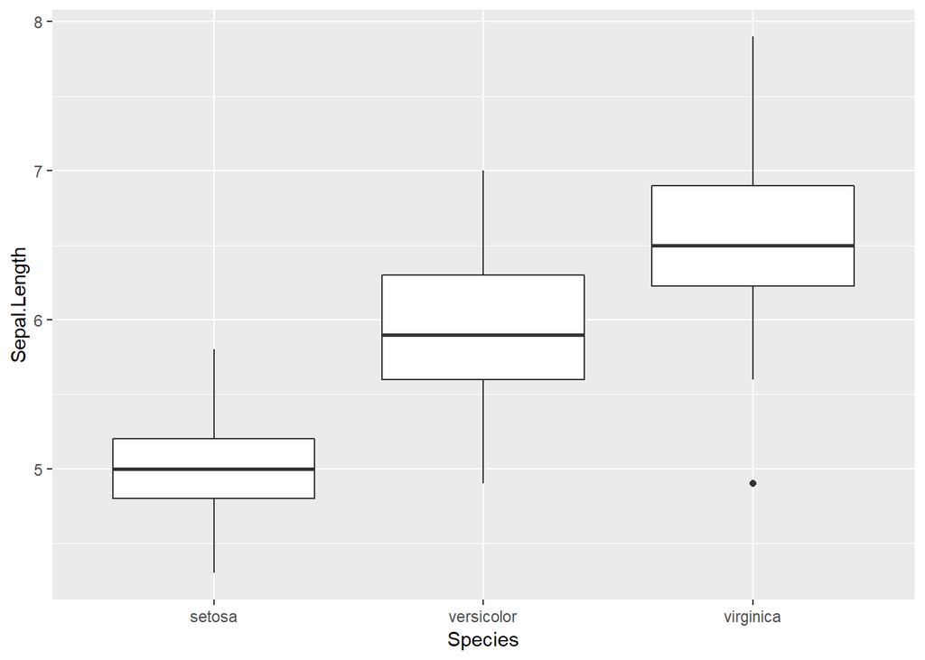

```r
ggplot(data = iris, aes(Species, Sepal.Length)) + geom_boxplot()
```

### Violin plots

A violin plot is more informative than a plain box plot. In fact while a box plot only shows summary statistics such as mean/median and interquartile ranges, the violin plot shows the full distribution of the data.

13. Make a violin plot of Sepal.Length by Species.

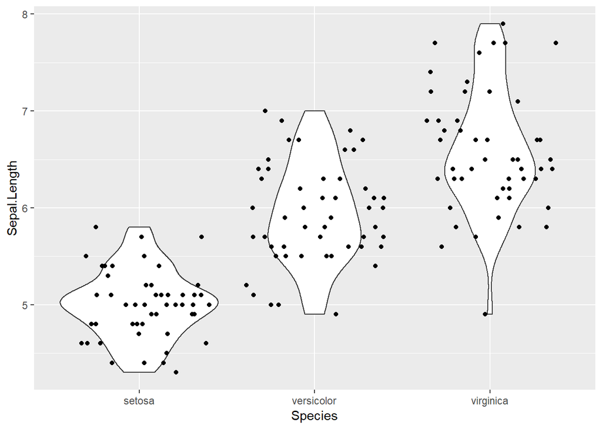

```r
ggplot(data = iris, aes(Species, Sepal.Length)) +  geom_violin() + geom_jitter(height = 0)
```

Can we generalize a function to make both boxplot and violin plot side by side?

Open multi_plots.R and lets walk through the function.

14. Plot Sepal.Length and Species using the MultiPlots function.

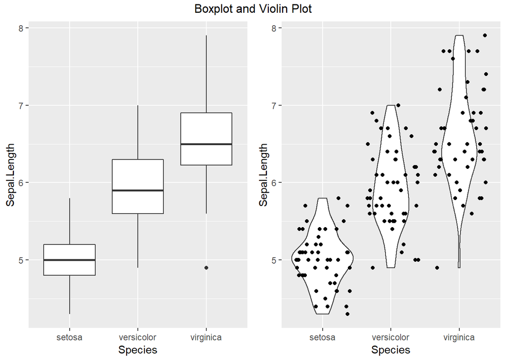

```r
source('multi_plots.R')
MultiPlots(iris, aes(Species, Sepal.Length), "Boxplot and Violin Plot")
```

15. Update the plot to color the different Species. Also extend the MultiPlots function to take a name for the y axis.

```r
MultiPlots <- function(data, mapping, labs, title) {
    library(ggplot2)
    library(grid)
    library(gridExtra)
    p1 = ggplot(data = data, mapping) + geom_boxplot() + labs
    p2 = ggplot(data = data, mapping) +  geom_violin() + geom_jitter(height = 0) + labs
    grid.arrange(p1, p2, ncol=2, top = title)
}
```

- Please fix the following function call:
- MultiPlots(iris, aes(Species, Sepal.Length, color=??), labs(y=“Length”), ??)
16. Extend the MultiPlots function to that you can plots Sepal.Width as both boxplot and violin plot in the same page. (Hint: Add a separate mapping argument for the other plots )

```r
MultiPlots <- function(data, mapping1, mapping2, title) {
    library(ggplot2)
    library(grid)
    library(gridExtra)
    p1 = ggplot(data = data, mapping1) + geom_boxplot()
    p2 = ggplot(data = data, mapping1) +  geom_violin() + geom_jitter(height = 0)
    p3 = ggplot(data = data, mapping2) + geom_boxplot()
    p4 = ggplot(data = data, mapping2) +  geom_violin() + geom_jitter(height = 0)
    grid.arrange(p1, p2, p3, p4, ncol=2, top = title)
}
```

- Please fix the following function call:
- MultiPlots(iris, aes(Species, Sepal.Length), ??, ??)
17. Update the MutliPlots function to make side by side plots of Sepal.Length and Sepal.Width, with boxplot in the middle of the violin plot to view the summary the data. (Hint: Change the width of the boxplot to fit inside the violin plot)

```r
MultiPlots <- function(data, mapping1, mapping2, title) {
    library(ggplot2)
    library(grid)
    library(gridExtra)
    p1 = ggplot(data = data, mapping1) + geom_violin()  + geom_boxplot(width=.1)
    p2 = ggplot(data = data, mapping2) +  geom_violin() + geom_boxplot(width=.1)
    grid.arrange(p1, p2, ncol=2, top = title)
}
```

- Please fix the following function call:
- MultiPlots(iris, ??, ??, ??)

### Scripts provide:

- reproducible â share the script and its results
- re-usable â analyze additional input data/files with the same command(s)
- extensible â never start analysis from scratch
- reliable â no danger of missing typing files

## Command line

Executing R scripts at the command line allows you to: * Automate your scripts * Integrate R into pipelines * Call R from other tools or systems

18. Install package “argparse”, open exp_plot.R script file, and
- Execute the following command in the terminal
- RScript exp_plot.R 1.25 6